[OHI British Columbia](http://www.ohibc.org/) | [OHI Science](http://ohi-science.org) | [Citation policy](https://github.com/OHI-Science/ohiprep/releases)

# Regress health and trend vs pressure groups

Compiled on Thu Feb 22 14:03:52 2018 by ohara

```r
knitr::opts_chunk$set(fig.width = 6, fig.height = 4, fig.path = 'Figs/',
                      echo = TRUE, message = FALSE, warning = FALSE)

library(raster)
library(sf)
library(fasterize)

source('~/github/src/R/common.R')  ###
  ### includes library(tidyverse); library(stringr); dir_M points to ohi directory

dir_git <- '~/github/spp_health_dists'

### goal specific folders and info
dir_data    <- file.path(dir_git, 'data')
dir_spatial <- file.path(dir_git, 'spatial')
dir_anx     <- file.path(dir_M, 'git-annex')
dir_o_anx   <- file.path(dir_O, 'git-annex/spp_health_dists')
# ### provenance tracking
library(provRmd); prov_setup()

### support scripts
source('~/github/src/R/rast_tools.R')
  ### raster plotting and analyzing scripts
```

# 1 Summary

At the LOICZID raster scale (0.5° cells), compare ecosystem risk and trends to pressures layers. Pressures are aggregated to LOICZID in a data_setup script.

# 2 Data Sources

# 3 Fishing pressures

## 3.1 Build data frame of pressure means and variances.

Read in the various fishing pressure layers from prs_to_loiczid folder. Join them.

```r
fis_prs_files <- list.files('prs_to_loiczid',
                            pattern = 'demersal|pelagic|artisanal',
                            full.names = TRUE)

rm(fis_prs_df)
for(prs_file in fis_prs_files) {  ### prs_file <- fis_prs_files[3]
  prs_name <- basename(prs_file) %>%
    str_replace('_combo_simple.csv', '')

  # cat('Processing', prs_name, '...\n')

  tmp <- read_csv(prs_file, col_types = 'dddii') %>%
    select(-n_na) %>%
    setNames(c('loiczid',
               paste0(prs_name, '_mean'), paste0(prs_name, '_var'),
               paste0(prs_name, '_zeros')))

  if(!exists('fis_prs_df')) {
    fis_prs_df <- tmp    ### create it the first time through the loop
  } else {
    fis_prs_df <- fis_prs_df %>%
      full_join(tmp, by = 'loiczid')     ### join it on subsequent times through the loop
  }
}

risk_df <- read_csv(file.path(dir_data, 'current_risk_by_loiczid.csv'),
                    col_types = 'ddddd')

risk_v_prs_df <- full_join(risk_df, fis_prs_df, by = 'loiczid')

fis_prs_mdl <- lm(mean_risk ~ artisanal_fishing_mean +
                    demersal_destructive_fishing_mean +
                    demersal_nondest_high_bycatch_mean +
                    pelagic_high_bycatch_mean +
                    pelagic_low_bycatch_mean,
                  data = risk_v_prs_df)

# summary(fis_prs_mdl)
### overall R^2 of about .0186
```

```r
poll_prs_files <- list.files('prs_to_loiczid',
                            pattern = 'inorg|poll|plume',
                            full.names = TRUE)

rm(poll_prs_df)
for(prs_file in poll_prs_files) {  ### prs_file <- poll_prs_files[3]
  prs_name <- basename(prs_file) %>%
    str_replace('_combo_simple.csv', '')

  # cat('Processing', prs_name, '...\n')

  tmp <- read_csv(prs_file, col_types = 'dddii') %>%
    select(-n_na) %>%
    setNames(c('loiczid',
               paste0(prs_name, '_mean'), paste0(prs_name, '_var'),
               paste0(prs_name, '_zeros')))

  if(!exists('poll_prs_df')) {
    poll_prs_df <- tmp    ### create it the first time through the loop
  } else {
    poll_prs_df <- poll_prs_df %>%
      full_join(tmp, by = 'loiczid')     ### join it on subsequent times through the loop
  }
}

risk_df <- read_csv(file.path(dir_data, 'current_risk_by_loiczid.csv'),
                    col_types = 'ddddd')

risk_v_prs_df <- full_join(risk_df, poll_prs_df, by = 'loiczid')

poll_prs_mdl <- lm(mean_risk ~ inorganic_mean +
                    ocean_pollution_mean +
                    plumes_fert_mean +
                    plumes_pest_mean,
                  data = risk_v_prs_df)

# summary(poll_prs_mdl)
### overall R^2 of about .0027
```

```r
other_prs_files <- list.files('prs_to_loiczid',
                            pattern = 'invasive|oil_rigs|night|pop|shipping',
                            full.names = TRUE)

rm(other_prs_df)
for(prs_file in other_prs_files) {  ### prs_file <- other_prs_files[3]
  prs_name <- basename(prs_file) %>%
    str_replace('_combo_simple.csv', '')

  # cat('Processing', prs_name, '...\n')

  tmp <- read_csv(prs_file, col_types = 'dddii') %>%
    select(-n_na) %>%
    setNames(c('loiczid',
               paste0(prs_name, '_mean'), paste0(prs_name, '_var'),
               paste0(prs_name, '_zeros')))

  if(!exists('other_prs_df')) {
    other_prs_df <- tmp    ### create it the first time through the loop
  } else {
    other_prs_df <- other_prs_df %>%
      full_join(tmp, by = 'loiczid')     ### join it on subsequent times through the loop
  }
}

risk_df <- read_csv(file.path(dir_data, 'current_risk_by_loiczid.csv'),
                    col_types = 'ddddd')

risk_v_prs_df <- full_join(risk_df, other_prs_df, by = 'loiczid')

other_prs_mdl <- lm(mean_risk ~ invasives_mean +
                      night_lights_mean +
                      oil_rigs_mean +
                      population_mean +
                      shipping_mean,
                  data = risk_v_prs_df)

# summary(other_prs_mdl)
### overall R^2 of about .004
```

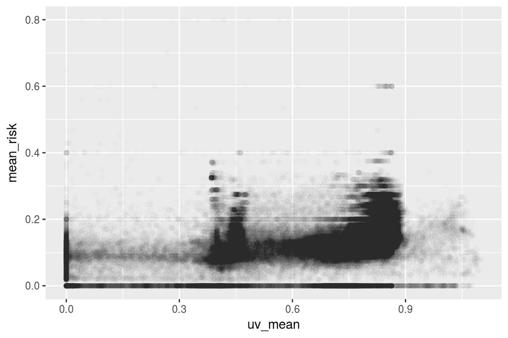

```r
cc_prs_files <- list.files('prs_to_loiczid',
                            pattern = 'slr|sst|uv|acid',
                            full.names = TRUE)

rm(cc_prs_df)
for(prs_file in cc_prs_files) {  ### prs_file <- cc_prs_files[3]
  prs_name <- basename(prs_file) %>%
    str_replace('_combo_simple.csv', '')

  # cat('Processing', prs_name, '...\n')

  tmp <- read_csv(prs_file, col_types = 'dddii') %>%
    select(-n_na) %>%
    setNames(c('loiczid',
               paste0(prs_name, '_mean'), paste0(prs_name, '_var'),
               paste0(prs_name, '_zeros')))

  if(!exists('cc_prs_df')) {
    cc_prs_df <- tmp    ### create it the first time through the loop
  } else {
    cc_prs_df <- cc_prs_df %>%
      full_join(tmp, by = 'loiczid')     ### join it on subsequent times through the loop
  }
}

risk_df <- read_csv(file.path(dir_data, 'current_risk_by_loiczid.csv'),
                    col_types = 'ddddd')

risk_v_prs_df <- full_join(risk_df, cc_prs_df, by = 'loiczid')

cc_prs_mdl1 <- lm(mean_risk ~ ocean_acidification_mean + ### on its own, R^2 = .0567
                    slr_mean + ### on its own, R^2 = .0198
                    sst_mean + ### on its own, R^2 = .0457
                    uv_mean,   ### on its own, R^2 = .2321, estimate = .149
                  data = risk_v_prs_df)

# summary(cc_prs_mdl)
### overall R^2 of about .2491
#
# lm(formula = mean_risk ~ ocean_acidification_mean + slr_mean +
#     sst_mean + uv_mean, data = risk_v_prs_df)
#
# Residuals:
#      Min       1Q   Median       3Q      Max
# -0.18961 -0.03230 -0.00785  0.03381  0.74510
#
# Coefficients:
#                           Estimate Std. Error t value Pr(>|t|)
# (Intercept)              0.0161118  0.0007317   22.02   <2e-16 ***
# ocean_acidification_mean 0.0106473  0.0007576   14.05   <2e-16 ***
# slr_mean                 0.0495576  0.0009001   55.06   <2e-16 ***
# sst_mean                 0.0046886  0.0002571   18.23   <2e-16 ***
# uv_mean                  0.1491433  0.0007626  195.56   <2e-16 ***
# ---
# Signif. codes:  0 ‘***’ 0.001 ‘**’ 0.01 ‘*’ 0.05 ‘.’ 0.1 ‘ ’ 1
#
# Residual standard error: 0.06043 on 159359 degrees of freedom
#   (22644 observations deleted due to missingness)
# Multiple R-squared:  0.2491,  Adjusted R-squared:  0.2491
# F-statistic: 1.322e+04 on 4 and 159359 DF,  p-value: < 2.2e-16

lat_df <- read_csv(file.path(dir_data, 'latitude_lookup.csv'), col_types = 'dd')

risk_v_prs_df <- risk_v_prs_df %>%
  left_join(lat_df, by = 'loiczid') %>%
  mutate(lat_abs = abs(lat))

cc_prs_mdl1 <- lm(mean_risk ~ uv_mean +   ### on its own, R^2 = .2321
                    # lat_abs +
                    # n_spp +
                    lat, ### on its own, R^2 = .0740
                  data = risk_v_prs_df)

# summary(cc_prs_mdl1)
### overall R^2 of about .255 with lat, and .234 with lat_abs (and .256 with both)

ggplot(risk_v_prs_df, aes(x = uv_mean, y = mean_risk)) +
  geom_point(alpha = .01)
```

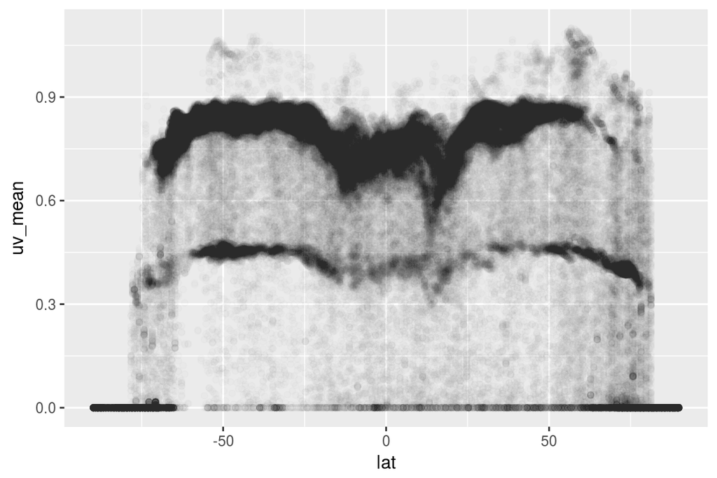

```r
ggplot(risk_v_prs_df, aes(x = lat, y = uv_mean)) +
  geom_point(alpha = .01)
```

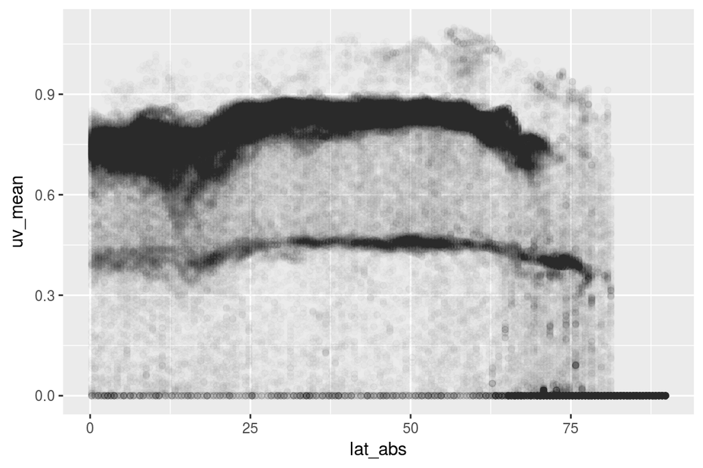

```r
ggplot(risk_v_prs_df, aes(x = lat_abs, y = uv_mean)) +
  geom_point(alpha = .01)
```

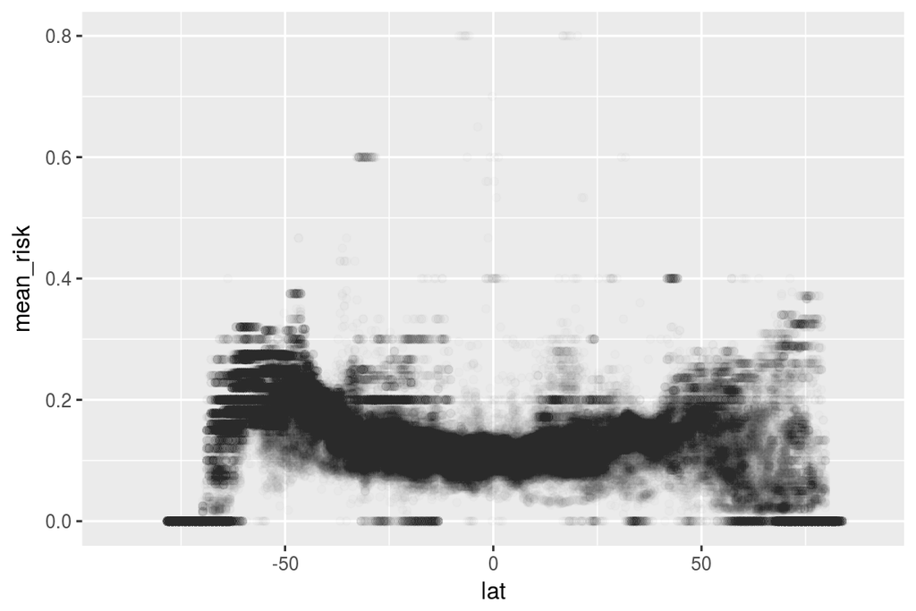

```r
ggplot(risk_v_prs_df, aes(x = lat, y = mean_risk)) +
  geom_point(alpha = .01)
```

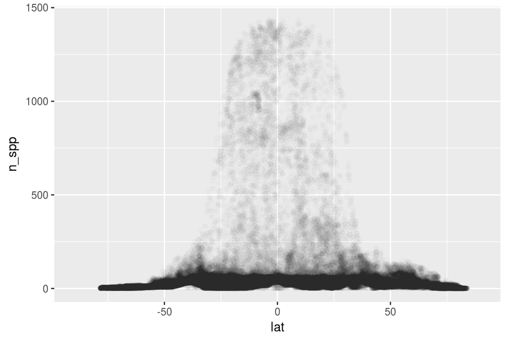

```r
ggplot(risk_v_prs_df, aes(x = lat, y = n_spp)) +
  geom_point(alpha = .01)
```

There seems to be a strong correlation between UV pressure (number of extreme UV events over five-year period) on its own and mean species extinction risk. This does not seem to be due to latitude-driven differences in UV events. Other possibilities?

```r
mean_risk_df <- read_csv(file.path(dir_data, 'current_risk_by_loiczid.csv'), col_types = 'dddii') %>%
  filter(n_spp > 5)
uv_df <- read_csv(file.path(dir_git, 'prs_to_loiczid/uv_combo_simple.csv'), col_types = 'ddddd')

loiczid_rast <- raster(file.path(dir_spatial, 'loiczid_raster.tif'))

risk_rast <- subs(loiczid_rast, mean_risk_df, by = 'loiczid', which = 'mean_risk')

uv_rast <- subs(loiczid_rast, uv_df, by = 'loiczid', which = 'prs_mean')
```

### 3.1.1 Mean spp risk (n_spp > 5)

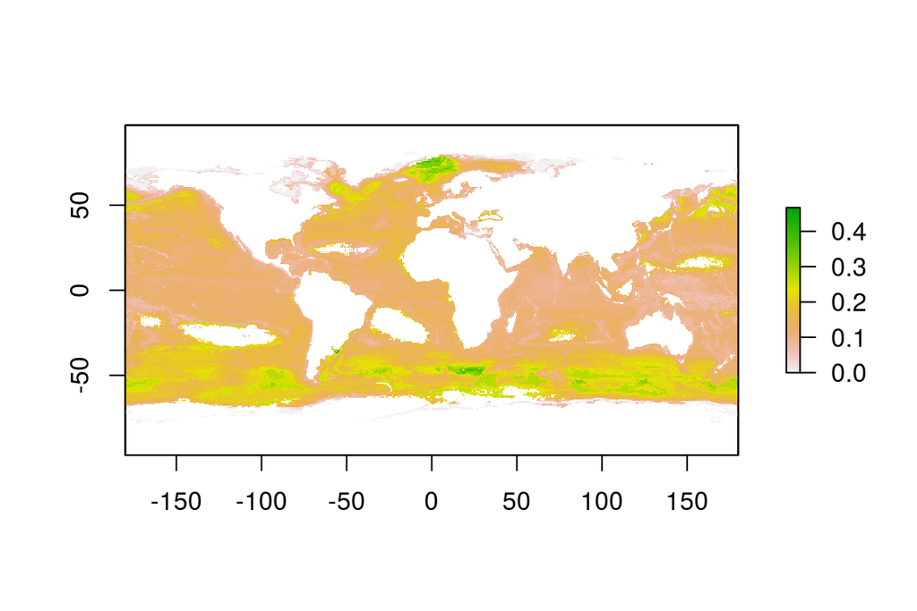

```r
plot(risk_rast)
```

### 3.1.2 UV pressure

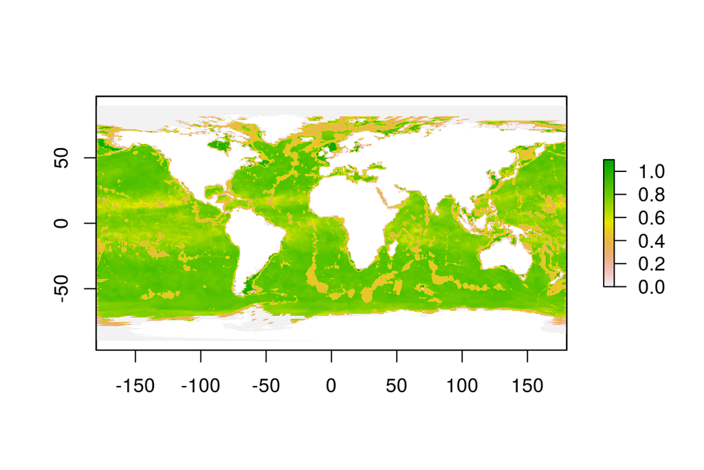

```r
plot(uv_rast)
```

Looks like the way that UV is rescaled as a pressure conforms to pelagic vs coastal/shallow. Why is UV pressure higher in open oceans rather than shallows where corals may occur? Is it related to NPP?

```r
prov_wrapup(commit_outputs = FALSE)
```

# 4 Provenance

- *Run ID: 5 (fdc987d); run tag: “standard run”*
- *Run elapsed time: 82.711 seconds; run memory usage: 5536.9 MB*
- *System info:*
  - *System: Linux, Release: 4.4.0-112-generic. Machine: x86_64. User: ohara.*
  - *R version: R version 3.4.3 (2017-11-30), Platform: x86_64-pc-linux-gnu, Running under: Ubuntu 14.04.5 LTS.*
  - *Attached base packages: stats, graphics, grDevices, utils, datasets, methods, base*
  - *Other attached packages: bindrcpp_0.2, provRmd_0.1.1, stringr_1.2.0, RColorBrewer_1.1-2, dplyr_0.7.2, purrr_0.2.3, readr_1.1.0, tidyr_0.7.0, tibble_1.3.4, ggplot2_2.2.1.9000, tidyverse_1.1.1, fasterize_0.1.0, sf_0.5-5, raster_2.5-8, sp_1.2-5*

[figure not shown]

| sequence | file_name | parent_chunk | file_dir | filetype | uncomm_chgs | commit_hash_short |
| --- | --- | --- | --- | --- | --- | --- |
| 0 | 1_regress_health_trend_pressures.Rmd | prov_footer | ~/github/spp_health_dists | parent_script |  |  |
| 0 | 1_regress_health_trend_pressures.Rmd#cc_prs | cc_prs | ~/github/spp_health_dists | parent_chunk |  |  |
| 0 | 1_regress_health_trend_pressures.Rmd#fis_prs | fis_prs | ~/github/spp_health_dists | parent_chunk |  |  |
| 0 | 1_regress_health_trend_pressures.Rmd#other_prs | other_prs | ~/github/spp_health_dists | parent_chunk |  |  |
| 0 | 1_regress_health_trend_pressures.Rmd#plot_uv_and_mean_risk | plot_uv_and_mean_risk | ~/github/spp_health_dists | parent_chunk |  |  |
| 0 | 1_regress_health_trend_pressures.Rmd#pollution_prs | pollution_prs | ~/github/spp_health_dists | parent_chunk |  |  |
| 0 | 1_regress_health_trend_pressures.Rmd#prov_footer | prov_footer | ~/github/spp_health_dists | parent_chunk |  |  |
| 0 | 1_regress_health_trend_pressures.Rmd#setup | setup | ~/github/spp_health_dists | parent_chunk |  |  |
| 1 | rast_tools.R | setup | ~/github/src/R | sourced_script |  |  |
| 2 | artisanal_fishing_combo_simple.csv | fis_prs | prs_to_loiczid | input | False | b110779 |

[output cut: 26 more lines]